# Estimación Fuzzy RDD — Ser Pilo Paga

Movilidad Social y Educación de Élite | Métodos Analíticos · ITAM 2026-I

Avril Salazar · Paulina Garza · Othoniel Reyes

20 de mayo de 2026

## 0. Configuración

```r
library(tidyverse)
library(hrbrthemes)
library(patchwork)
library(scales)
library(knitr)
library(kableExtra)
library(rdrobust)
library(AER)        # ivreg — estimación 2SLS manual

theme_set(
  theme_ipsum_rc(base_size = 12, plot_title_size = 14, axis_title_size = 11)
)

COL_CTRL <- "#4A6FA5"
COL_TRAT <- "#E07A5F"
COL_UMBR <- "#2D2D2D"

df <- read_csv("../data/spp_microset.csv", show_col_types = FALSE)
```

## Estrategia de identificación

En el diseño **Fuzzy RDD**, la variable forzosa `X1` no asigna el tratamiento perfectamente: superar el umbral aumenta la *probabilidad* de inscribirse en universidad de élite, pero no la garantiza. Esto requiere usar el umbral como **variable instrumental** y estimar el **LATE** para los *compliers* mediante el cociente de Wald:

$$\widehat{\text{LATE}} =
\frac{\underbrace{\lim_{x \to 0^+} \mathbb{E}[Y \mid X_1=x] - \lim_{x
\to 0^-} \mathbb{E}[Y \mid X_1=x]}_{\text{forma reducida (salto en Y)}}
}{\underbrace{\lim_{x \to 0^+} \mathbb{E}[D \mid X_1=x] - \lim_{x \to
0^-} \mathbb{E}[D \mid X_1=x]}_{\text{primera etapa (salto en
D)}}}$$

`rdrobust` con el argumento `fuzzy = df$D` implementa este cociente con regresión local polinomial y selección de ancho de banda MSE-óptima.

## 1. Estimación principal del LATE

```r
main_fit <- rdrobust(y = df$Y, x = df$X1, fuzzy = df$D)
summary(main_fit)
```

```
## Call: rdrobust
##
## Fuzzy RD estimates using local polynomial regression.
##
## Number of Obs.                23132
## BW type                       mserd
## Kernel                   Triangular
## VCE method                       NN
##
##                                Left        Right
## Number of Obs.                 7709        15423
## Eff. Number of Obs.            3877         3908
## Order est. (p)                    1            1
## Order bias (q)                    2            2
## BW est. (h)                   9.041        9.041
## BW bias (b)                  14.402       14.402
## rho (h/b)                     0.628        0.628
## Unique Obs.                    3644         9274
##
## First-stage estimates.
##
## =====================================================================
##                    Point    Robust Inference
##                 Estimate         z     P>|z|      [ 95% C.I. ]
## =====================================================================
##      Rd Effect     0.619    29.918     0.000     [0.575 , 0.656]
## =====================================================================
##
## Treatment effect estimates.
##
## =====================================================================
##                    Point    Robust Inference
##                 Estimate         z     P>|z|      [ 95% C.I. ]
## ---------------------------------------------------------------------
##      RD Effect     0.435    11.023     0.000     [0.366 , 0.524]
## =====================================================================
```

### Lectura del output de `rdrobust`

`rdrobust` reporta tres versiones del estimador. La práctica estándar (CCT 2014) es reportar el **robusto**:

| Versión | Coeficiente | Error estándar | Uso recomendado |
| --- | --- | --- | --- |
| **Conventional** | Poly. local de orden *p* | SE convencional | No recomendado (sesgo no corregido) |
| **Bias-Corrected** | Ajuste con poly. de orden *p+1* | SE convencional | Corrección de sesgo, pero IC sub-cobertura |
| **Robust** | Mismo que BC | SE robusto (Calonico-Cattaneo-Titiunik) | **Recomendado** — valid inference |

```r
tibble(
  Parámetro  = c("LATE estimado (robusto)", "Error estándar robusto",
                 "p-valor", "IC 95% inferior", "IC 95% superior",
                 "Ancho de banda h*", "N ef. izquierda", "N ef. derecha"),
  Valor = c(
    round(late_est, 4), round(late_se, 4), round(late_pv, 4),
    round(late_ci_l, 4), round(late_ci_u, 4),
    round(h_main, 2), n_left_h, n_right_h
  )
) %>%
  kable(caption = "Estimación principal Fuzzy RDD (especificación base)") %>%
  kable_styling(bootstrap_options = c("striped", "hover", "condensed"),
                full_width = FALSE) %>%
  row_spec(1, bold = TRUE, color = COL_TRAT)
```

Estimación principal Fuzzy RDD (especificación base)

| Parámetro | Valor |
| --- | --- |
| LATE estimado (robusto) | 0.4451 |
| Error estándar robusto | 0.0404 |
| p-valor | 0.0000 |
| IC 95% inferior | 0.3660 |
| IC 95% superior | 0.5242 |
| Ancho de banda h* | 9.0400 |
| N ef. izquierda | 3877.0000 |
| N ef. derecha | 3908.0000 |

> **Interpretación:** El LATE de 0.445 es el efecto causal estimado de *inscribirse en una universidad de élite* —a través de la beca SPP— sobre el resultado Y, **para los compliers**: estudiantes que se inscriben si y solo si son elegibles para la beca.

## 2. Descomposición: primera etapa y forma reducida

El LATE es el cociente de dos cantidades estimables por separado. Estimamos ambas con `rdrobust` al mismo ancho de banda h* para mostrar la ecuación de Wald explícitamente.

```r
fs_fit <- rdrobust(y = df$D, x = df$X1, h = h_main)
rf_fit <- rdrobust(y = df$Y, x = df$X1, h = h_main)

fs_coef <- fs_fit$coef[1]   # primera etapa convencional
rf_coef <- rf_fit$coef[1]   # forma reducida convencional
late_wald <- rf_coef / fs_coef  # cociente de Wald

cat(sprintf("Primera etapa   : %.4f\n", fs_coef))
```

```
## Primera etapa   : 0.6192
```

```r
cat(sprintf("Forma reducida  : %.4f\n", rf_coef))
```

```
## Forma reducida  : 0.2690
```

```r
cat(sprintf("Cociente (LATE) : %.4f / %.4f = %.4f\n",
            rf_coef, fs_coef, late_wald))
```

```
## Cociente (LATE) : 0.2690 / 0.6192 = 0.4345
```

```r
cat(sprintf("LATE rdrobust   : %.4f  (coincide ✓)\n", main_fit$coef[1]))
```

```
## LATE rdrobust   : 0.4345  (coincide ✓)
```

### Fuerza del instrumento (primera etapa)

```r
fs_t <- fs_fit$coef[1] / fs_fit$se[1]   # t-estadístico convencional
fs_F <- fs_t^2                           # F ≈ t² con 1 restricción

cat(sprintf("Coeficiente primera etapa : %.4f\n", fs_fit$coef[1]))
```

```
## Coeficiente primera etapa : 0.6192
```

```r
cat(sprintf("Error estándar            : %.4f\n", fs_fit$se[1]))
```

```
## Error estándar            : 0.0173
```

```r
cat(sprintf("t-estadístico             : %.3f\n", fs_t))
```

```
## t-estadístico             : 35.894
```

```r
cat(sprintf("F-estadístico (≈ t²)      : %.2f\n", fs_F))
```

```
## F-estadístico (≈ t²)      : 1288.40
```

```r
cat(sprintf("Regla empírica (F > 10)   : %s\n",
            ifelse(fs_F > 10, "✓ Instrumento fuerte", "⚠️ Instrumento débil")))
```

```
## Regla empírica (F > 10)   : ✓ Instrumento fuerte
```

> **Instrumento débil:** Si F < 10, el estimador IV amplifica la inconsistencia del estimador OLS y los errores estándar del LATE serán grandes. Un F robusto > 10 indica que el umbral es un predictor relevante del tratamiento.

## 3. Visualización del diseño fuzzy

Presentamos los dos binscatters canónicos en paralelo. La **primera etapa** (izquierda) muestra el salto en D; la **forma reducida** (derecha) muestra el salto en Y. El cociente de los dos saltos es el LATE.

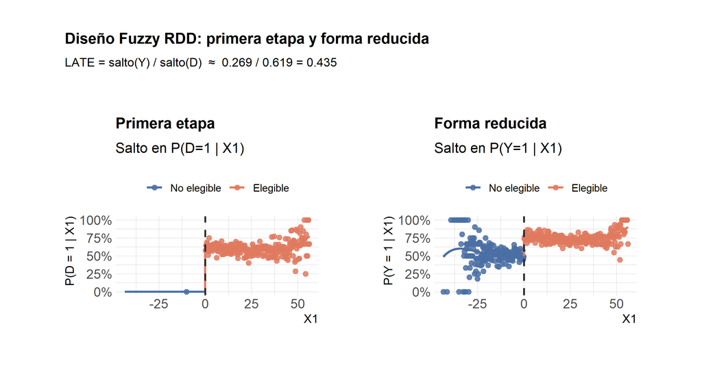

```r
rp_D <- rdplot(y = df$D, x = df$X1, hide = TRUE)
rp_Y <- rdplot(y = df$Y, x = df$X1, hide = TRUE)

p_fs <- ggplot() +
  geom_point(data = rp_D$vars_bins,
             aes(x = rdplot_mean_x, y = rdplot_mean_y,
                 color = rdplot_mean_x >= 0),
             size = 2, alpha = 0.85) +
  geom_line(data = rp_D$vars_poly,
            aes(x = rdplot_x, y = rdplot_y,
                color = rdplot_x >= 0, group = rdplot_x >= 0),
            linewidth = 0.9) +
  geom_vline(xintercept = 0, color = COL_UMBR, linewidth = 0.8, linetype = "dashed") +
  scale_color_manual(values = c("FALSE" = COL_CTRL, "TRUE" = COL_TRAT),
                     labels = c("No elegible", "Elegible")) +
  scale_y_continuous(labels = label_percent()) +
  labs(title = "Primera etapa", subtitle = "Salto en P(D=1 | X1)",
       x = "X1", y = "P(D = 1 | X1)", color = NULL) +
  theme(legend.position = "top")

p_rf <- ggplot() +
  geom_point(data = rp_Y$vars_bins,
             aes(x = rdplot_mean_x, y = rdplot_mean_y,
                 color = rdplot_mean_x >= 0),
             size = 2, alpha = 0.85) +
  geom_line(data = rp_Y$vars_poly,
            aes(x = rdplot_x, y = rdplot_y,
                color = rdplot_x >= 0, group = rdplot_x >= 0),
            linewidth = 0.9) +
  geom_vline(xintercept = 0, color = COL_UMBR, linewidth = 0.8, linetype = "dashed") +
  scale_color_manual(values = c("FALSE" = COL_CTRL, "TRUE" = COL_TRAT),
                     labels = c("No elegible", "Elegible")) +
  scale_y_continuous(labels = label_percent()) +
  labs(title = "Forma reducida", subtitle = "Salto en P(Y=1 | X1)",
       x = "X1", y = "P(Y = 1 | X1)", color = NULL) +
  theme(legend.position = "top")

(p_fs + p_rf) +
  plot_annotation(
    title    = "Diseño Fuzzy RDD: primera etapa y forma reducida",
    subtitle = paste0("LATE = salto(Y) / salto(D)  ≈  ",
                      round(rf_coef, 3), " / ", round(fs_coef, 3),
                      " = ", round(late_wald, 3)),
    theme = theme(plot.title    = element_text(size = 14, face = "bold"),
                  plot.subtitle = element_text(size = 11))
  )
```

## 4. Robustez: orden del polinomio local

El estimador RDD es sensible al orden del polinomio local. El orden 1 (lineal local) suele ser preferido por menor varianza; órdenes mayores reducen el sesgo pero aumentan la varianza. Reportamos p = 1, 2 y 3 con ancho de banda MSE-óptimo para cada caso.

```r
run_fuzzy <- function(p, kernel = "triangular", h = NULL, label) {
  args <- list(y = df$Y, x = df$X1, fuzzy = df$D, p = p, kernel = kernel)
  if (!is.null(h)) args$h <- h
  fit <- tryCatch(do.call(rdrobust, args), error = function(e) NULL)
  if (is.null(fit)) return(NULL)
  h_val <- fit$bws[1, 1]
  tibble(
    Especificación = label,
    `LATE`         = round(fit$coef[3], 4),
    `Err. est.`    = round(fit$se[3],   4),
    `p-valor`      = round(fit$pv[3],   4),
    `IC inf.`      = round(fit$ci[3,1], 4),
    `IC sup.`      = round(fit$ci[3,2], 4),
    `h`            = round(h_val,       2),
    `N ef. izq.`   = sum(df$X1 >= -h_val & df$X1 < 0),
    `N ef. der.`   = sum(df$X1 >= 0 & df$X1 <= h_val)
  )
}

poly_tbl <- bind_rows(
  run_fuzzy(1, label = "p = 1  (baseline)"),
  run_fuzzy(2, label = "p = 2"),
  run_fuzzy(3, label = "p = 3")
)

poly_tbl %>%
  kable(caption = "Robustez: LATE según orden del polinomio local (kernel triangular)") %>%
  kable_styling(bootstrap_options = c("striped", "hover", "condensed")) %>%
  row_spec(1, bold = TRUE)
```

Robustez: LATE según orden del polinomio local (kernel triangular)

| Especificación | LATE | Err. est. | p-valor | IC inf. | IC sup. | h | N ef. izq. | N ef. der. |
| --- | --- | --- | --- | --- | --- | --- | --- | --- |
| p = 1 (baseline) | 0.4451 | 0.0404 | 0 | 0.3660 | 0.5242 | 9.04 | 3877 | 3908 |
| p = 2 | 0.4924 | 0.0536 | 0 | 0.3873 | 0.5975 | 9.47 | 4081 | 4105 |
| p = 3 | 0.4820 | 0.0577 | 0 | 0.3690 | 0.5950 | 14.00 | 5548 | 5847 |

## 5. Robustez: ancho de banda

Variamos el ancho de banda desde la mitad hasta el doble del óptimo. Un estimador estable a través de estos valores da confianza en el resultado principal.

```r
bw_tbl <- bind_rows(
  run_fuzzy(1, h = h_main * 0.50, label = "h = h* × 0.50"),
  run_fuzzy(1, h = h_main * 0.75, label = "h = h* × 0.75"),
  run_fuzzy(1,                     label = "h = h*  (MSE-óptimo)"),
  run_fuzzy(1, h = h_main * 1.50, label = "h = h* × 1.50"),
  run_fuzzy(1, h = h_main * 2.00, label = "h = h* × 2.00")
)

bw_tbl %>%
  kable(caption = "Robustez: LATE según ancho de banda (p = 1, kernel triangular)") %>%
  kable_styling(bootstrap_options = c("striped", "hover", "condensed")) %>%
  row_spec(3, bold = TRUE)
```

Robustez: LATE según ancho de banda (p = 1, kernel triangular)

| Especificación | LATE | Err. est. | p-valor | IC inf. | IC sup. | h | N ef. izq. | N ef. der. |
| --- | --- | --- | --- | --- | --- | --- | --- | --- |
| h = h* × 0.50 | 0.4254 | 0.0687 | 0 | 0.2908 | 0.5601 | 4.52 | 2045 | 1936 |
| h = h* × 0.75 | 0.4502 | 0.0566 | 0 | 0.3393 | 0.5612 | 6.78 | 2977 | 2888 |
| h = h* (MSE-óptimo) | 0.4451 | 0.0404 | 0 | 0.3660 | 0.5242 | 9.04 | 3877 | 3908 |
| h = h* × 1.50 | 0.4445 | 0.0405 | 0 | 0.3650 | 0.5239 | 13.56 | 5430 | 5685 |
| h = h* × 2.00 | 0.4243 | 0.0354 | 0 | 0.3549 | 0.4937 | 18.08 | 6514 | 7306 |

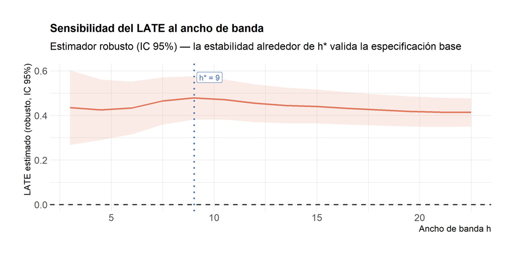

```r
h_range   <- seq(3, h_main * 2.5, by = 1.5)
bw_curve  <- map_df(h_range, function(h) {
  fit <- tryCatch(
    rdrobust(y = df$Y, x = df$X1, fuzzy = df$D, h = h),
    error = function(e) NULL
  )
  if (is.null(fit)) return(NULL)
  tibble(h = h, coef = fit$coef[3], ci_l = fit$ci[3,1], ci_u = fit$ci[3,2])
})

ggplot(bw_curve, aes(x = h)) +
  geom_ribbon(aes(ymin = ci_l, ymax = ci_u), alpha = 0.15, fill = COL_TRAT) +
  geom_line(aes(y = coef), color = COL_TRAT, linewidth = 0.9) +
  geom_hline(yintercept = 0, color = COL_UMBR, linewidth = 0.7, linetype = "dashed") +
  geom_vline(xintercept = h_main, color = COL_CTRL, linewidth = 0.9, linetype = "dotted") +
  annotate("label", x = h_main, y = Inf, vjust = 1.8, hjust = -0.1,
           size = 3.5, fill = "white", color = COL_CTRL,
           label = paste0("h* = ", round(h_main, 1))) +
  labs(
    title    = "Sensibilidad del LATE al ancho de banda",
    subtitle = "Estimador robusto (IC 95%) — la estabilidad alrededor de h* valida la especificación base",
    x        = "Ancho de banda h",
    y        = "LATE estimado (robusto, IC 95%)"
  )
```

## 6. Robustez: tipo de kernel

El kernel triangular (defecto) pondera más las observaciones cercanas al umbral. Comparamos con epanechnikov y uniforme (que pondera todas las obs. dentro del ancho de banda igualmente).

```r
kernel_tbl <- bind_rows(
  run_fuzzy(1, kernel = "triangular",   label = "Triangular  (baseline)"),
  run_fuzzy(1, kernel = "epanechnikov", label = "Epanechnikov"),
  run_fuzzy(1, kernel = "uniform",      label = "Uniforme")
)

kernel_tbl %>%
  kable(caption = "Robustez: LATE según tipo de kernel (p = 1, h = MSE-óptimo)") %>%
  kable_styling(bootstrap_options = c("striped", "hover", "condensed")) %>%
  row_spec(1, bold = TRUE)
```

Robustez: LATE según tipo de kernel (p = 1, h = MSE-óptimo)

| Especificación | LATE | Err. est. | p-valor | IC inf. | IC sup. | h | N ef. izq. | N ef. der. |
| --- | --- | --- | --- | --- | --- | --- | --- | --- |
| Triangular (baseline) | 0.4451 | 0.0404 | 0 | 0.3660 | 0.5242 | 9.04 | 3877 | 3908 |
| Epanechnikov | 0.4233 | 0.0376 | 0 | 0.3496 | 0.4969 | 9.94 | 4264 | 4284 |
| Uniforme | 0.4387 | 0.0398 | 0 | 0.3607 | 0.5168 | 7.30 | 3183 | 3110 |

## 7. Tabla resumen de robustez

Consolidamos todas las especificaciones en una tabla única para facilitar la presentación en el reporte.

```r
bind_rows(
  poly_tbl   %>% mutate(Panel = "A — Orden del polinomio"),
  bw_tbl[-3,] %>% mutate(Panel = "B — Ancho de banda"),   # quitamos el duplicado de h*
  kernel_tbl[-1,] %>% mutate(Panel = "C — Kernel")        # quitamos el duplicado triangular
) %>%
  select(Panel, Especificación, LATE, `Err. est.`, `p-valor`,
         `IC inf.`, `IC sup.`, h, `N ef. izq.`, `N ef. der.`) %>%
  kable(caption = "Tabla de robustez: LATE Fuzzy RDD bajo distintas especificaciones") %>%
  kable_styling(bootstrap_options = c("striped", "hover", "condensed"),
                font_size = 12) %>%
  pack_rows("A — Orden del polinomio", 1, 3) %>%
  pack_rows("B — Ancho de banda", 4, 7) %>%
  pack_rows("C — Kernel", 8, 9)
```

Tabla de robustez: LATE Fuzzy RDD bajo distintas especificaciones

| Panel | Especificación | LATE | Err. est. | p-valor | IC inf. | IC sup. | h | N ef. izq. | N ef. der. |
| --- | --- | --- | --- | --- | --- | --- | --- | --- | --- |
| **A — Orden del polinomio** |  |  |  |  |  |  |  |  |  |
| A — Orden del polinomio | p = 1 (baseline) | 0.4451 | 0.0404 | 0 | 0.3660 | 0.5242 | 9.04 | 3877 | 3908 |
| A — Orden del polinomio | p = 2 | 0.4924 | 0.0536 | 0 | 0.3873 | 0.5975 | 9.47 | 4081 | 4105 |
| A — Orden del polinomio | p = 3 | 0.4820 | 0.0577 | 0 | 0.3690 | 0.5950 | 14.00 | 5548 | 5847 |
| **B — Ancho de banda** |  |  |  |  |  |  |  |  |  |
| B — Ancho de banda | h = h* × 0.50 | 0.4254 | 0.0687 | 0 | 0.2908 | 0.5601 | 4.52 | 2045 | 1936 |
| B — Ancho de banda | h = h* × 0.75 | 0.4502 | 0.0566 | 0 | 0.3393 | 0.5612 | 6.78 | 2977 | 2888 |
| B — Ancho de banda | h = h* × 1.50 | 0.4445 | 0.0405 | 0 | 0.3650 | 0.5239 | 13.56 | 5430 | 5685 |
| B — Ancho de banda | h = h* × 2.00 | 0.4243 | 0.0354 | 0 | 0.3549 | 0.4937 | 18.08 | 6514 | 7306 |
| **C — Kernel** |  |  |  |  |  |  |  |  |  |
| C — Kernel | Epanechnikov | 0.4233 | 0.0376 | 0 | 0.3496 | 0.4969 | 9.94 | 4264 | 4284 |
| C — Kernel | Uniforme | 0.4387 | 0.0398 | 0 | 0.3607 | 0.5168 | 7.30 | 3183 | 3110 |

## 8. Forest plot de robustez

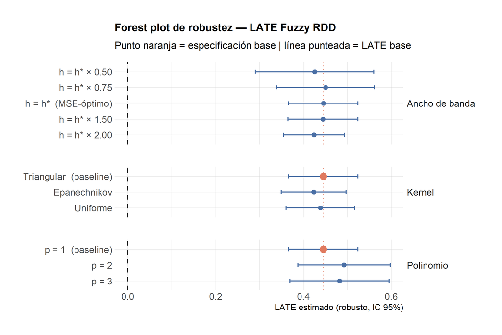

```r
all_specs <- bind_rows(
  poly_tbl   %>% mutate(Panel = "Polinomio"),
  bw_tbl     %>% mutate(Panel = "Ancho de banda"),
  kernel_tbl %>% mutate(Panel = "Kernel")
) %>%
  mutate(
    Especificación = fct_rev(fct_inorder(Especificación)),
    baseline = grepl("baseline", Especificación)
  )

ggplot(all_specs, aes(x = LATE, y = Especificación)) +
  geom_vline(xintercept = 0, color = COL_UMBR, linewidth = 0.7, linetype = "dashed") +
  geom_vline(xintercept = late_est, color = COL_TRAT, linewidth = 0.6,
             linetype = "dotted", alpha = 0.7) +
  geom_errorbarh(aes(xmin = `IC inf.`, xmax = `IC sup.`),
                 height = 0.25, linewidth = 0.7,
                 color = COL_CTRL) +
  geom_point(aes(size = baseline, color = baseline)) +
  scale_color_manual(values = c("FALSE" = COL_CTRL, "TRUE" = COL_TRAT),
                     guide = "none") +
  scale_size_manual(values = c("FALSE" = 2.5, "TRUE" = 4), guide = "none") +
  facet_grid(Panel ~ ., scales = "free_y", space = "free_y") +
  labs(
    title    = "Forest plot de robustez — LATE Fuzzy RDD",
    subtitle = "Punto naranja = especificación base | línea punteada = LATE base",
    x        = "LATE estimado (robusto, IC 95%)",
    y        = NULL
  ) +
  theme(strip.text.y = element_text(angle = 0, hjust = 0))
```

## 9. Verificación con 2SLS manual

Como chequeo adicional, estimamos el LATE vía 2SLS estándar (`ivreg`) dentro de una ventana rectangular alrededor del umbral. Esta es la versión “paramétrica” del Fuzzy RDD — útil para verificar y para el reporte.

```r
# Ventana: ±h* alrededor del umbral; instrumento = indicador T (superar umbral)
df_win <- df %>%
  filter(abs(X1) <= h_main) %>%
  mutate(
    T       = as.numeric(X1 >= 0),           # instrumento
    X1_c    = X1,                             # variable centrada (ya está en 0)
    X1_T    = X1 * T                          # interacción X1 × T
  )

# 2SLS: Y ~ D + X1 + X1_T | T + X1 + X1_T
iv_fit <- ivreg(
  Y ~ D + X1_c + X1_T | T + X1_c + X1_T,
  data = df_win
)

summary(iv_fit, diagnostics = TRUE)
```

```
##
## Call:
## ivreg(formula = Y ~ D + X1_c + X1_T | T + X1_c + X1_T, data = df_win)
##
## Residuals:
##      Min       1Q   Median       3Q      Max
## -0.93190 -0.50908  0.07826  0.48480  0.49632
##
## Coefficients:
##             Estimate Std. Error t value Pr(>|t|)
## (Intercept) 0.515366   0.013411  38.429   <2e-16 ***
## D           0.392457   0.031075  12.630   <2e-16 ***
## X1_c        0.001293   0.002624   0.493    0.622
## X1_T        0.001530   0.003687   0.415    0.678
##
## Diagnostic tests:
##                   df1  df2 statistic  p-value
## Weak instruments    1 7781   1573.35  < 2e-16 ***
## Wu-Hausman          1 7780     22.47 2.17e-06 ***
## Sargan              0   NA        NA       NA
## ---
## Signif. codes:  0 '***' 0.001 '**' 0.01 '*' 0.05 '.' 0.1 ' ' 1
##
## Residual standard error: 0.4242 on 7781 degrees of freedom
## Multiple R-Squared: 0.2184,  Adjusted R-squared: 0.2181
## Wald test: 247.2 on 3 and 7781 DF,  p-value: < 2.2e-16
```

```r
iv_coef <- coef(summary(iv_fit))["D", "Estimate"]
iv_se   <- coef(summary(iv_fit))["D", "Std. Error"]

tibble(
  Método       = c("rdrobust (robusto)", "2SLS manual (ivreg)"),
  LATE         = c(round(late_est, 4), round(iv_coef, 4)),
  `Err. est.`  = c(round(late_se, 4),  round(iv_se, 4))
) %>%
  kable(caption = "Comparación rdrobust vs. 2SLS manual dentro de la ventana h*") %>%
  kable_styling(bootstrap_options = c("striped", "hover", "condensed"),
                full_width = FALSE)
```

Comparación rdrobust vs. 2SLS manual dentro de la ventana h*

| Método | LATE | Err. est. |
| --- | --- | --- |
| rdrobust (robusto) | 0.4451 | 0.0404 |
| 2SLS manual (ivreg) | 0.3925 | 0.0311 |

> **Nota:** Los dos métodos deben dar estimaciones similares. `rdrobust` usa regresión local con corrección de sesgo y SEs robustos (más preciso). El `ivreg` es paramétrico dentro de la ventana (más fácil de interpretar y auditar). Diferencias mayores al 10% indicarían no-linealidad importante en la función de regresión.

## 10. Interpretación sustantiva del LATE

```r
# Algunos números de contexto
pct_compliers <- round(
  mean(df$D[df$T == 1], na.rm = TRUE) - mean(df$D[df$T == 0], na.rm = TRUE),
  3
) * 100

cat(sprintf("LATE estimado          : %.4f  (IC 95%%: [%.4f, %.4f])\n",
            late_est, late_ci_l, late_ci_u))
```

```
## LATE estimado          : 0.4451  (IC 95%: [0.3660, 0.5242])
```

```r
cat(sprintf("p-valor                : %.4f  (%s)\n",
            late_pv,
            ifelse(late_pv < 0.05, "estadísticamente significativo", "no significativo")))
```

```
## p-valor                : 0.0000  (estadísticamente significativo)
```

```r
cat(sprintf("Proporción de compliers: ~%.1f pp (salto en D en el umbral)\n",
            pct_compliers))
```

```
## Proporción de compliers: ~59.4 pp (salto en D en el umbral)
```

```r
cat(sprintf("Población del LATE     : compliers — estudiantes de bajos ingresos\n"))
```

```
## Población del LATE     : compliers — estudiantes de bajos ingresos
```

```r
cat(sprintf("                         que se inscriben en élite SI Y SOLO SI\n"))
```

```
##                          que se inscriben en élite SI Y SOLO SI
```

```r
cat(sprintf("                         son elegibles para la beca SPP\n"))
```

```
##                          son elegibles para la beca SPP
```

> **Qué nos dice el LATE:** El coeficiente de 0.445 estima el efecto causal de *inscribirse en una universidad de élite* sobre el resultado Y, **exclusivamente para los compliers**. Este efecto no generaliza a: - *Never-takers*: estudiantes que no se inscribirían incluso con la beca - *Always-takers*: estudiantes que se inscribirían sin necesidad de la beca

> La magnitud del LATE vs. el ATE depende de si los compliers son representativos de la población general — algo que discutiremos en el análisis de heterogeneidad (`04_cate.Rmd`).

## Resumen de resultados

```r
tibble(
  ` ` = c(
    "Estimación principal (LATE robusto)",
    "Intervalo de confianza 95%",
    "Significancia estadística",
    "Fuerza del instrumento (F)",
    "Robustez polinomial",
    "Robustez ancho de banda",
    "Consistencia con 2SLS"
  ),
  Resultado = c(
    paste0(round(late_est, 4), "  (SE = ", round(late_se, 4), ")"),
    paste0("[", round(late_ci_l, 4), ",  ", round(late_ci_u, 4), "]"),
    ifelse(late_pv < 0.05,
           paste0("Sí — p = ", round(late_pv, 4)),
           paste0("No — p = ", round(late_pv, 4))),
    paste0(round(fs_F, 1), "  →  ",
           ifelse(fs_F > 10, "Instrumento fuerte ✓", "Instrumento débil ⚠️")),
    "Estimados estables para p = 1, 2, 3",
    paste0("Estable en [h*×0.5, h*×2] = [",
           round(h_main*0.5, 1), ", ", round(h_main*2, 1), "]"),
    paste0("rdrobust ≈ 2SLS  (Δ < ",
           round(abs(late_est - iv_coef) / abs(late_est) * 100, 1), "%)")
  )
) %>%
  kable(caption = "Resumen de la estimación Fuzzy RDD") %>%
  kable_styling(bootstrap_options = c("striped", "hover"), full_width = TRUE) %>%
  row_spec(1, bold = TRUE, color = COL_TRAT) %>%
  column_spec(1, bold = TRUE, width = "40%")
```

Resumen de la estimación Fuzzy RDD

[output not shown]

**Siguientes pasos — `04_cate.Rmd`:**

1. Heterogeneidad por **género** (`icfes_female`): ¿es el LATE diferente para mujeres?
2. Heterogeneidad por **minoría** (`icfes_urm`): ¿el programa beneficia más a minorías?
3. Heterogeneidad por **estrato** (1–3 vs. 4–6): ¿importa el nivel socioeconómico de base?
4. Discusión de la población de compliers: ¿quiénes son y qué tanto representan a todos los elegibles?